# Risk Factor Analysis

## Outcome Variable

**Outcome Variable:** wast_rec90d

## Predictor Variables

**Intervention Variable:** nrooms

**Adjustment Set:**

unadjusted

## Stratifying Variables

The analysis was stratified on these variable(s):

- agecat
- studyid
- country

## Data Summary

| agecat | studyid | country | nrooms | wast_rec90d | n_cell | n |
| --- | --- | --- | --- | --- | --- | --- |
| 0-24 months | ki0047075b-MAL-ED | BANGLADESH | 1 | 0 | 32 | 121 |
| 0-24 months | ki0047075b-MAL-ED | BANGLADESH | 1 | 1 | 61 | 121 |
| 0-24 months | ki0047075b-MAL-ED | BANGLADESH | 2 | 0 | 7 | 121 |
| 0-24 months | ki0047075b-MAL-ED | BANGLADESH | 2 | 1 | 9 | 121 |
| 0-24 months | ki0047075b-MAL-ED | BANGLADESH | 3 | 0 | 2 | 121 |
| 0-24 months | ki0047075b-MAL-ED | BANGLADESH | 3 | 1 | 6 | 121 |
| 0-24 months | ki0047075b-MAL-ED | BANGLADESH | 4+ | 0 | 3 | 121 |
| 0-24 months | ki0047075b-MAL-ED | BANGLADESH | 4+ | 1 | 1 | 121 |
| 0-24 months | ki0047075b-MAL-ED | BRAZIL | 1 | 0 | 0 | 23 |
| 0-24 months | ki0047075b-MAL-ED | BRAZIL | 1 | 1 | 0 | 23 |
| 0-24 months | ki0047075b-MAL-ED | BRAZIL | 2 | 0 | 0 | 23 |
| 0-24 months | ki0047075b-MAL-ED | BRAZIL | 2 | 1 | 2 | 23 |
| 0-24 months | ki0047075b-MAL-ED | BRAZIL | 3 | 0 | 1 | 23 |
| 0-24 months | ki0047075b-MAL-ED | BRAZIL | 3 | 1 | 3 | 23 |
| 0-24 months | ki0047075b-MAL-ED | BRAZIL | 4+ | 0 | 5 | 23 |
| 0-24 months | ki0047075b-MAL-ED | BRAZIL | 4+ | 1 | 12 | 23 |
| 0-24 months | ki0047075b-MAL-ED | INDIA | 1 | 0 | 27 | 173 |
| 0-24 months | ki0047075b-MAL-ED | INDIA | 1 | 1 | 38 | 173 |
| 0-24 months | ki0047075b-MAL-ED | INDIA | 2 | 0 | 23 | 173 |
| 0-24 months | ki0047075b-MAL-ED | INDIA | 2 | 1 | 41 | 173 |
| 0-24 months | ki0047075b-MAL-ED | INDIA | 3 | 0 | 14 | 173 |
| 0-24 months | ki0047075b-MAL-ED | INDIA | 3 | 1 | 18 | 173 |
| 0-24 months | ki0047075b-MAL-ED | INDIA | 4+ | 0 | 3 | 173 |
| 0-24 months | ki0047075b-MAL-ED | INDIA | 4+ | 1 | 9 | 173 |
| 0-24 months | ki0047075b-MAL-ED | NEPAL | 1 | 0 | 4 | 92 |
| 0-24 months | ki0047075b-MAL-ED | NEPAL | 1 | 1 | 23 | 92 |
| 0-24 months | ki0047075b-MAL-ED | NEPAL | 2 | 0 | 1 | 92 |
| 0-24 months | ki0047075b-MAL-ED | NEPAL | 2 | 1 | 5 | 92 |
| 0-24 months | ki0047075b-MAL-ED | NEPAL | 3 | 0 | 0 | 92 |
| 0-24 months | ki0047075b-MAL-ED | NEPAL | 3 | 1 | 6 | 92 |

[output cut: 354 more lines]

The following strata were considered:

- agecat: 0-24 months, studyid: ki0047075b-MAL-ED, country: BANGLADESH
- agecat: 0-24 months, studyid: ki0047075b-MAL-ED, country: BRAZIL
- agecat: 0-24 months, studyid: ki0047075b-MAL-ED, country: INDIA
- agecat: 0-24 months, studyid: ki0047075b-MAL-ED, country: NEPAL
- agecat: 0-24 months, studyid: ki0047075b-MAL-ED, country: PERU
- agecat: 0-24 months, studyid: ki0047075b-MAL-ED, country: SOUTH AFRICA
- agecat: 0-24 months, studyid: ki0047075b-MAL-ED, country: TANZANIA, UNITED REPUBLIC OF
- agecat: 0-24 months, studyid: ki1000108-CMC-V-BCS-2002, country: INDIA
- agecat: 0-24 months, studyid: ki1000108-IRC, country: INDIA
- agecat: 0-24 months, studyid: ki1017093b-PROVIDE, country: BANGLADESH
- agecat: 0-24 months, studyid: ki1017093c-NIH-Crypto, country: BANGLADESH
- agecat: 0-24 months, studyid: ki1113344-GMS-Nepal, country: NEPAL
- agecat: 0-24 months, studyid: ki1114097-CONTENT, country: PERU
- agecat: 0-24 months, studyid: ki1135781-COHORTS, country: INDIA
- agecat: 0-24 months, studyid: kiGH5241-JiVitA-3, country: BANGLADESH
- agecat: 0-24 months, studyid: kiGH5241-JiVitA-4, country: BANGLADESH
- agecat: 0-6 months, studyid: ki0047075b-MAL-ED, country: BANGLADESH
- agecat: 0-6 months, studyid: ki0047075b-MAL-ED, country: BRAZIL
- agecat: 0-6 months, studyid: ki0047075b-MAL-ED, country: INDIA
- agecat: 0-6 months, studyid: ki0047075b-MAL-ED, country: NEPAL
- agecat: 0-6 months, studyid: ki0047075b-MAL-ED, country: PERU
- agecat: 0-6 months, studyid: ki0047075b-MAL-ED, country: SOUTH AFRICA
- agecat: 0-6 months, studyid: ki0047075b-MAL-ED, country: TANZANIA, UNITED REPUBLIC OF
- agecat: 0-6 months, studyid: ki1000108-CMC-V-BCS-2002, country: INDIA
- agecat: 0-6 months, studyid: ki1000108-IRC, country: INDIA
- agecat: 0-6 months, studyid: ki1017093b-PROVIDE, country: BANGLADESH
- agecat: 0-6 months, studyid: ki1017093c-NIH-Crypto, country: BANGLADESH
- agecat: 0-6 months, studyid: ki1113344-GMS-Nepal, country: NEPAL
- agecat: 0-6 months, studyid: ki1114097-CONTENT, country: PERU
- agecat: 0-6 months, studyid: ki1135781-COHORTS, country: INDIA
- agecat: 0-6 months, studyid: kiGH5241-JiVitA-3, country: BANGLADESH
- agecat: 0-6 months, studyid: kiGH5241-JiVitA-4, country: BANGLADESH
- agecat: 6-24 months, studyid: ki0047075b-MAL-ED, country: BANGLADESH
- agecat: 6-24 months, studyid: ki0047075b-MAL-ED, country: BRAZIL
- agecat: 6-24 months, studyid: ki0047075b-MAL-ED, country: INDIA
- agecat: 6-24 months, studyid: ki0047075b-MAL-ED, country: NEPAL
- agecat: 6-24 months, studyid: ki0047075b-MAL-ED, country: PERU
- agecat: 6-24 months, studyid: ki0047075b-MAL-ED, country: SOUTH AFRICA
- agecat: 6-24 months, studyid: ki0047075b-MAL-ED, country: TANZANIA, UNITED REPUBLIC OF
- agecat: 6-24 months, studyid: ki1000108-CMC-V-BCS-2002, country: INDIA
- agecat: 6-24 months, studyid: ki1000108-IRC, country: INDIA
- agecat: 6-24 months, studyid: ki1017093b-PROVIDE, country: BANGLADESH
- agecat: 6-24 months, studyid: ki1017093c-NIH-Crypto, country: BANGLADESH
- agecat: 6-24 months, studyid: ki1113344-GMS-Nepal, country: NEPAL
- agecat: 6-24 months, studyid: ki1114097-CONTENT, country: PERU
- agecat: 6-24 months, studyid: ki1135781-COHORTS, country: INDIA
- agecat: 6-24 months, studyid: kiGH5241-JiVitA-3, country: BANGLADESH
- agecat: 6-24 months, studyid: kiGH5241-JiVitA-4, country: BANGLADESH

### Dropped Strata

Some strata were dropped due to rare outcomes:

- agecat: 0-24 months, studyid: ki0047075b-MAL-ED, country: BANGLADESH
- agecat: 0-24 months, studyid: ki0047075b-MAL-ED, country: BRAZIL
- agecat: 0-24 months, studyid: ki0047075b-MAL-ED, country: INDIA
- agecat: 0-24 months, studyid: ki0047075b-MAL-ED, country: NEPAL
- agecat: 0-24 months, studyid: ki0047075b-MAL-ED, country: PERU
- agecat: 0-24 months, studyid: ki0047075b-MAL-ED, country: SOUTH AFRICA
- agecat: 0-24 months, studyid: ki0047075b-MAL-ED, country: TANZANIA, UNITED REPUBLIC OF
- agecat: 0-24 months, studyid: ki1000108-CMC-V-BCS-2002, country: INDIA
- agecat: 0-24 months, studyid: ki1017093b-PROVIDE, country: BANGLADESH
- agecat: 0-24 months, studyid: ki1114097-CONTENT, country: PERU
- agecat: 0-24 months, studyid: ki1135781-COHORTS, country: INDIA
- agecat: 0-6 months, studyid: ki0047075b-MAL-ED, country: BANGLADESH
- agecat: 0-6 months, studyid: ki0047075b-MAL-ED, country: BRAZIL
- agecat: 0-6 months, studyid: ki0047075b-MAL-ED, country: INDIA
- agecat: 0-6 months, studyid: ki0047075b-MAL-ED, country: NEPAL
- agecat: 0-6 months, studyid: ki0047075b-MAL-ED, country: PERU
- agecat: 0-6 months, studyid: ki0047075b-MAL-ED, country: SOUTH AFRICA
- agecat: 0-6 months, studyid: ki0047075b-MAL-ED, country: TANZANIA, UNITED REPUBLIC OF
- agecat: 0-6 months, studyid: ki1000108-CMC-V-BCS-2002, country: INDIA
- agecat: 0-6 months, studyid: ki1000108-IRC, country: INDIA
- agecat: 0-6 months, studyid: ki1017093b-PROVIDE, country: BANGLADESH
- agecat: 0-6 months, studyid: ki1017093c-NIH-Crypto, country: BANGLADESH
- agecat: 0-6 months, studyid: ki1114097-CONTENT, country: PERU
- agecat: 0-6 months, studyid: ki1135781-COHORTS, country: INDIA
- agecat: 6-24 months, studyid: ki0047075b-MAL-ED, country: BANGLADESH
- agecat: 6-24 months, studyid: ki0047075b-MAL-ED, country: BRAZIL
- agecat: 6-24 months, studyid: ki0047075b-MAL-ED, country: INDIA
- agecat: 6-24 months, studyid: ki0047075b-MAL-ED, country: NEPAL
- agecat: 6-24 months, studyid: ki0047075b-MAL-ED, country: PERU
- agecat: 6-24 months, studyid: ki0047075b-MAL-ED, country: SOUTH AFRICA
- agecat: 6-24 months, studyid: ki0047075b-MAL-ED, country: TANZANIA, UNITED REPUBLIC OF
- agecat: 6-24 months, studyid: ki1000108-CMC-V-BCS-2002, country: INDIA
- agecat: 6-24 months, studyid: ki1000108-IRC, country: INDIA
- agecat: 6-24 months, studyid: ki1017093b-PROVIDE, country: BANGLADESH
- agecat: 6-24 months, studyid: ki1017093c-NIH-Crypto, country: BANGLADESH
- agecat: 6-24 months, studyid: ki1114097-CONTENT, country: PERU
- agecat: 6-24 months, studyid: ki1135781-COHORTS, country: INDIA
- agecat: 6-24 months, studyid: kiGH5241-JiVitA-3, country: BANGLADESH

## Methods Detail

We’re interested in the causal parameters $E[Y_a]$ for all values of $a \in \mathcal{A}$. These parameters represent the mean outcome if, possibly contrary to fact, we intervened to set all units to have $A=a$. Under the randomization and positivity assumptions, these are identified by the statistical parameters $\psi_a=E_W[E_{Y|A,W}(Y|A=a,W)]$. In addition, we’re interested in the mean of $Y$, $E[Y]$ under no intervention (the observed mean). We will estimate these parameters by using SuperLearner to fit the relevant likelihood factors – $E_{Y|A,W}(Y|A=a,W)$ and $p(A=a|W)$, and then updating our likelihood fit using a joint TMLE.

For unadjusted analyses ($W=\{\}$), initial likelihoods were estimated using Lrnr_glm to estimate the simple $E(Y|A)$ and Lrnr_mean to estimate $p(A)$. For adjusted analyses, a small library containing Lrnr_glmnet, Lrnr_xgboost, and Lrnr_mean was used.

Having estimated these parameters, we will then use the delta method to estimate relative risks and attributable risks relative to a prespecified baseline level of $A$.

# Results Detail

## Results Plots

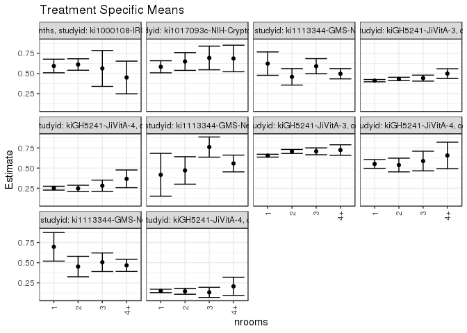

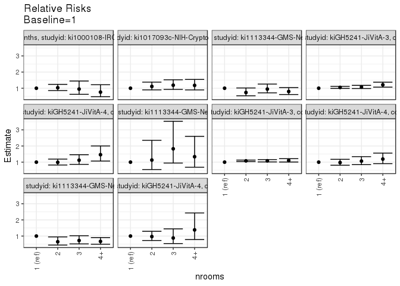

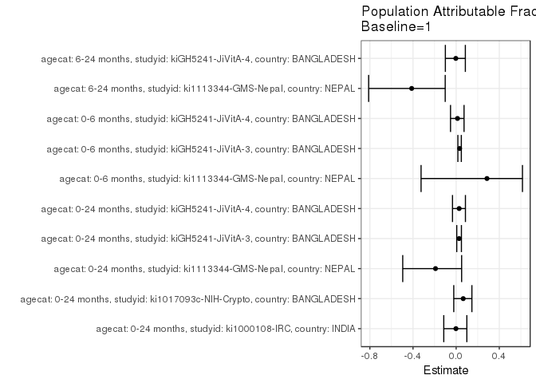

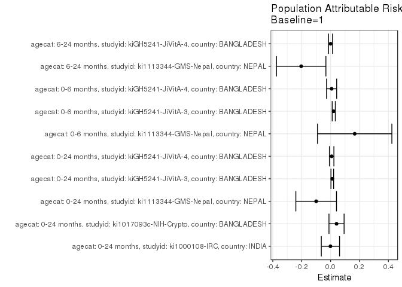

## Results Table

### Parameter: TSM

| agecat | studyid | country | intervention_level | baseline_level | estimate | ci_lower | ci_upper |
| --- | --- | --- | --- | --- | --- | --- | --- |
| 0-24 months | ki1000108-IRC | INDIA | 1 | NA | 0.5925926 | 0.5081592 | 0.6770260 |
| 0-24 months | ki1000108-IRC | INDIA | 2 | NA | 0.6111111 | 0.5401543 | 0.6820679 |
| 0-24 months | ki1000108-IRC | INDIA | 3 | NA | 0.5625000 | 0.3398407 | 0.7851593 |
| 0-24 months | ki1000108-IRC | INDIA | 4+ | NA | 0.4500000 | 0.2471890 | 0.6528110 |
| 0-24 months | ki1017093c-NIH-Crypto | BANGLADESH | 1 | NA | 0.5828221 | 0.5078896 | 0.6577545 |
| 0-24 months | ki1017093c-NIH-Crypto | BANGLADESH | 2 | NA | 0.6486486 | 0.5383045 | 0.7589928 |
| 0-24 months | ki1017093c-NIH-Crypto | BANGLADESH | 3 | NA | 0.6923077 | 0.5454181 | 0.8391972 |
| 0-24 months | ki1017093c-NIH-Crypto | BANGLADESH | 4+ | NA | 0.6857143 | 0.5210625 | 0.8503660 |
| 0-24 months | ki1113344-GMS-Nepal | NEPAL | 1 | NA | 0.6222222 | 0.4772128 | 0.7672316 |
| 0-24 months | ki1113344-GMS-Nepal | NEPAL | 2 | NA | 0.4579439 | 0.3557393 | 0.5601485 |
| 0-24 months | ki1113344-GMS-Nepal | NEPAL | 3 | NA | 0.5899281 | 0.4961167 | 0.6837394 |
| 0-24 months | ki1113344-GMS-Nepal | NEPAL | 4+ | NA | 0.4962963 | 0.4328205 | 0.5597721 |
| 0-24 months | kiGH5241-JiVitA-3 | BANGLADESH | 1 | NA | 0.4110619 | 0.3967049 | 0.4254190 |
| 0-24 months | kiGH5241-JiVitA-3 | BANGLADESH | 2 | NA | 0.4317308 | 0.4105649 | 0.4528967 |
| 0-24 months | kiGH5241-JiVitA-3 | BANGLADESH | 3 | NA | 0.4422254 | 0.4052652 | 0.4791855 |
| 0-24 months | kiGH5241-JiVitA-3 | BANGLADESH | 4+ | NA | 0.4980989 | 0.4376619 | 0.5585358 |
| 0-24 months | kiGH5241-JiVitA-4 | BANGLADESH | 1 | NA | 0.2507837 | 0.2270319 | 0.2745355 |
| 0-24 months | kiGH5241-JiVitA-4 | BANGLADESH | 2 | NA | 0.2480159 | 0.2088977 | 0.2871340 |
| 0-24 months | kiGH5241-JiVitA-4 | BANGLADESH | 3 | NA | 0.2812500 | 0.2120372 | 0.3504628 |
| 0-24 months | kiGH5241-JiVitA-4 | BANGLADESH | 4+ | NA | 0.3666667 | 0.2567234 | 0.4766099 |
| 0-6 months | ki1113344-GMS-Nepal | NEPAL | 1 | NA | 0.4166667 | 0.1509081 | 0.6824252 |
| 0-6 months | ki1113344-GMS-Nepal | NEPAL | 2 | NA | 0.4705882 | 0.3004500 | 0.6407264 |
| 0-6 months | ki1113344-GMS-Nepal | NEPAL | 3 | NA | 0.7608696 | 0.6358674 | 0.8858717 |
| 0-6 months | ki1113344-GMS-Nepal | NEPAL | 4+ | NA | 0.5568182 | 0.4527929 | 0.6608435 |
| 0-6 months | kiGH5241-JiVitA-3 | BANGLADESH | 1 | NA | 0.6537650 | 0.6362711 | 0.6712588 |
| 0-6 months | kiGH5241-JiVitA-3 | BANGLADESH | 2 | NA | 0.7059748 | 0.6809241 | 0.7310256 |
| 0-6 months | kiGH5241-JiVitA-3 | BANGLADESH | 3 | NA | 0.7077626 | 0.6652765 | 0.7502486 |
| 0-6 months | kiGH5241-JiVitA-3 | BANGLADESH | 4+ | NA | 0.7237569 | 0.6585820 | 0.7889318 |
| 0-6 months | kiGH5241-JiVitA-4 | BANGLADESH | 1 | NA | 0.5514019 | 0.4969447 | 0.6058590 |
| 0-6 months | kiGH5241-JiVitA-4 | BANGLADESH | 2 | NA | 0.5378788 | 0.4527497 | 0.6230079 |
| 0-6 months | kiGH5241-JiVitA-4 | BANGLADESH | 3 | NA | 0.5873016 | 0.4656210 | 0.7089822 |
| 0-6 months | kiGH5241-JiVitA-4 | BANGLADESH | 4+ | NA | 0.6562500 | 0.4915378 | 0.8209622 |
| 6-24 months | ki1113344-GMS-Nepal | NEPAL | 1 | NA | 0.6969697 | 0.5197034 | 0.8742360 |
| 6-24 months | ki1113344-GMS-Nepal | NEPAL | 2 | NA | 0.4520548 | 0.3251598 | 0.5789498 |
| 6-24 months | ki1113344-GMS-Nepal | NEPAL | 3 | NA | 0.5053763 | 0.3899301 | 0.6208226 |
| 6-24 months | ki1113344-GMS-Nepal | NEPAL | 4+ | NA | 0.4670330 | 0.3911401 | 0.5429259 |
| 6-24 months | kiGH5241-JiVitA-4 | BANGLADESH | 1 | NA | 0.1497382 | 0.1283680 | 0.1711084 |
| 6-24 months | kiGH5241-JiVitA-4 | BANGLADESH | 2 | NA | 0.1451613 | 0.1085956 | 0.1817269 |
| 6-24 months | kiGH5241-JiVitA-4 | BANGLADESH | 3 | NA | 0.1317829 | 0.0692086 | 0.1943573 |
| 6-24 months | kiGH5241-JiVitA-4 | BANGLADESH | 4+ | NA | 0.2068966 | 0.0939355 | 0.3198576 |

### Parameter: E(Y)

| agecat | studyid | country | intervention_level | baseline_level | estimate | ci_lower | ci_upper |
| --- | --- | --- | --- | --- | --- | --- | --- |
| 0-24 months | ki1000108-IRC | INDIA | NA | NA | 0.5913706 | 0.5391835 | 0.6435576 |
| 0-24 months | ki1017093c-NIH-Crypto | BANGLADESH | NA | NA | 0.6237942 | 0.5698223 | 0.6777662 |
| 0-24 months | ki1113344-GMS-Nepal | NEPAL | NA | NA | 0.5222816 | 0.4773852 | 0.5671781 |
| 0-24 months | kiGH5241-JiVitA-3 | BANGLADESH | NA | NA | 0.4226600 | 0.4115317 | 0.4337883 |
| 0-24 months | kiGH5241-JiVitA-4 | BANGLADESH | NA | NA | 0.2580019 | 0.2386523 | 0.2773515 |
| 0-6 months | ki1113344-GMS-Nepal | NEPAL | NA | NA | 0.5833333 | 0.5108676 | 0.6557991 |
| 0-6 months | kiGH5241-JiVitA-3 | BANGLADESH | NA | NA | 0.6754701 | 0.6621313 | 0.6888089 |
| 0-6 months | kiGH5241-JiVitA-4 | BANGLADESH | NA | NA | 0.5583942 | 0.5167799 | 0.6000084 |
| 6-24 months | ki1113344-GMS-Nepal | NEPAL | NA | NA | 0.4934383 | 0.4388573 | 0.5480193 |
| 6-24 months | kiGH5241-JiVitA-4 | BANGLADESH | NA | NA | 0.1492734 | 0.1316631 | 0.1668838 |

### Parameter: RR

| agecat | studyid | country | intervention_level | baseline_level | estimate | ci_lower | ci_upper |
| --- | --- | --- | --- | --- | --- | --- | --- |
| 0-24 months | ki1000108-IRC | INDIA | 1 | 1 | 1.0000000 | 1.0000000 | 1.0000000 |
| 0-24 months | ki1000108-IRC | INDIA | 2 | 1 | 1.0312500 | 0.8580769 | 1.2393722 |
| 0-24 months | ki1000108-IRC | INDIA | 3 | 1 | 0.9492188 | 0.6232698 | 1.4456279 |
| 0-24 months | ki1000108-IRC | INDIA | 4+ | 1 | 0.7593750 | 0.4733474 | 1.2182394 |
| 0-24 months | ki1017093c-NIH-Crypto | BANGLADESH | 1 | 1 | 1.0000000 | 1.0000000 | 1.0000000 |
| 0-24 months | ki1017093c-NIH-Crypto | BANGLADESH | 2 | 1 | 1.1129445 | 0.8989008 | 1.3779558 |
| 0-24 months | ki1017093c-NIH-Crypto | BANGLADESH | 3 | 1 | 1.1878543 | 0.9265560 | 1.5228412 |
| 0-24 months | ki1017093c-NIH-Crypto | BANGLADESH | 4+ | 1 | 1.1765414 | 0.8960725 | 1.5447964 |
| 0-24 months | ki1113344-GMS-Nepal | NEPAL | 1 | 1 | 1.0000000 | 1.0000000 | 1.0000000 |
| 0-24 months | ki1113344-GMS-Nepal | NEPAL | 2 | 1 | 0.7359813 | 0.5329026 | 1.0164493 |
| 0-24 months | ki1113344-GMS-Nepal | NEPAL | 3 | 1 | 0.9480987 | 0.7149671 | 1.2572481 |
| 0-24 months | ki1113344-GMS-Nepal | NEPAL | 4+ | 1 | 0.7976190 | 0.6114204 | 1.0405216 |
| 0-24 months | kiGH5241-JiVitA-3 | BANGLADESH | 1 | 1 | 1.0000000 | 1.0000000 | 1.0000000 |
| 0-24 months | kiGH5241-JiVitA-3 | BANGLADESH | 2 | 1 | 1.0502815 | 0.9889253 | 1.1154445 |
| 0-24 months | kiGH5241-JiVitA-3 | BANGLADESH | 3 | 1 | 1.0758120 | 0.9826459 | 1.1778114 |
| 0-24 months | kiGH5241-JiVitA-3 | BANGLADESH | 4+ | 1 | 1.2117367 | 1.0680052 | 1.3748115 |
| 0-24 months | kiGH5241-JiVitA-4 | BANGLADESH | 1 | 1 | 1.0000000 | 1.0000000 | 1.0000000 |
| 0-24 months | kiGH5241-JiVitA-4 | BANGLADESH | 2 | 1 | 0.9889633 | 0.8227570 | 1.1887452 |
| 0-24 months | kiGH5241-JiVitA-4 | BANGLADESH | 3 | 1 | 1.1214844 | 0.8615611 | 1.4598235 |
| 0-24 months | kiGH5241-JiVitA-4 | BANGLADESH | 4+ | 1 | 1.4620833 | 1.0676169 | 2.0022985 |
| 0-6 months | ki1113344-GMS-Nepal | NEPAL | 1 | 1 | 1.0000000 | 1.0000000 | 1.0000000 |
| 0-6 months | ki1113344-GMS-Nepal | NEPAL | 2 | 1 | 1.1294118 | 0.5425546 | 2.3510464 |
| 0-6 months | ki1113344-GMS-Nepal | NEPAL | 3 | 1 | 1.8260870 | 0.9451006 | 3.5282949 |
| 0-6 months | ki1113344-GMS-Nepal | NEPAL | 4+ | 1 | 1.3363636 | 0.6875221 | 2.5975422 |
| 0-6 months | kiGH5241-JiVitA-3 | BANGLADESH | 1 | 1 | 1.0000000 | 1.0000000 | 1.0000000 |
| 0-6 months | kiGH5241-JiVitA-3 | BANGLADESH | 2 | 1 | 1.0798603 | 1.0329195 | 1.1289344 |
| 0-6 months | kiGH5241-JiVitA-3 | BANGLADESH | 3 | 1 | 1.0825948 | 1.0137316 | 1.1561360 |
| 0-6 months | kiGH5241-JiVitA-3 | BANGLADESH | 4+ | 1 | 1.1070598 | 1.0077955 | 1.2161013 |
| 0-6 months | kiGH5241-JiVitA-4 | BANGLADESH | 1 | 1 | 1.0000000 | 1.0000000 | 1.0000000 |
| 0-6 months | kiGH5241-JiVitA-4 | BANGLADESH | 2 | 1 | 0.9754751 | 0.8094622 | 1.1755356 |
| 0-6 months | kiGH5241-JiVitA-4 | BANGLADESH | 3 | 1 | 1.0651063 | 0.8466683 | 1.3399005 |
| 0-6 months | kiGH5241-JiVitA-4 | BANGLADESH | 4+ | 1 | 1.1901483 | 0.9087877 | 1.5586181 |
| 6-24 months | ki1113344-GMS-Nepal | NEPAL | 1 | 1 | 1.0000000 | 1.0000000 | 1.0000000 |
| 6-24 months | ki1113344-GMS-Nepal | NEPAL | 2 | 1 | 0.6486004 | 0.4440138 | 0.9474536 |
| 6-24 months | ki1113344-GMS-Nepal | NEPAL | 3 | 1 | 0.7251052 | 0.5151021 | 1.0207249 |
| 6-24 months | ki1113344-GMS-Nepal | NEPAL | 4+ | 1 | 0.6700908 | 0.4954356 | 0.9063169 |
| 6-24 months | kiGH5241-JiVitA-4 | BANGLADESH | 1 | 1 | 1.0000000 | 1.0000000 | 1.0000000 |
| 6-24 months | kiGH5241-JiVitA-4 | BANGLADESH | 2 | 1 | 0.9694338 | 0.7257231 | 1.2949869 |
| 6-24 months | kiGH5241-JiVitA-4 | BANGLADESH | 3 | 1 | 0.8800889 | 0.5360545 | 1.4449211 |
| 6-24 months | kiGH5241-JiVitA-4 | BANGLADESH | 4+ | 1 | 1.3817217 | 0.7858663 | 2.4293635 |

### Parameter: PAR

| agecat | studyid | country | intervention_level | baseline_level | estimate | ci_lower | ci_upper |
| --- | --- | --- | --- | --- | --- | --- | --- |
| 0-24 months | ki1000108-IRC | INDIA | 1 | NA | -0.0012220 | -0.0643943 | 0.0619503 |
| 0-24 months | ki1017093c-NIH-Crypto | BANGLADESH | 1 | NA | 0.0409721 | -0.0113008 | 0.0932450 |
| 0-24 months | ki1113344-GMS-Nepal | NEPAL | 1 | NA | -0.0999406 | -0.2405496 | 0.0406685 |
| 0-24 months | kiGH5241-JiVitA-3 | BANGLADESH | 1 | NA | 0.0115980 | 0.0024558 | 0.0207402 |
| 0-24 months | kiGH5241-JiVitA-4 | BANGLADESH | 1 | NA | 0.0072182 | -0.0082731 | 0.0227096 |
| 0-6 months | ki1113344-GMS-Nepal | NEPAL | 1 | NA | 0.1666667 | -0.0904389 | 0.4237722 |
| 0-6 months | kiGH5241-JiVitA-3 | BANGLADESH | 1 | NA | 0.0217051 | 0.0109147 | 0.0324956 |
| 0-6 months | kiGH5241-JiVitA-4 | BANGLADESH | 1 | NA | 0.0069923 | -0.0279799 | 0.0419645 |
| 6-24 months | ki1113344-GMS-Nepal | NEPAL | 1 | NA | -0.2035314 | -0.3744911 | -0.0325717 |
| 6-24 months | kiGH5241-JiVitA-4 | BANGLADESH | 1 | NA | -0.0004648 | -0.0142748 | 0.0133452 |

### Parameter: PAF

| agecat | studyid | country | intervention_level | baseline_level | estimate | ci_lower | ci_upper |
| --- | --- | --- | --- | --- | --- | --- | --- |
| 0-24 months | ki1000108-IRC | INDIA | 1 | NA | -0.0020664 | -0.1147791 | 0.0992501 |
| 0-24 months | ki1017093c-NIH-Crypto | BANGLADESH | 1 | NA | 0.0656821 | -0.0221660 | 0.1459803 |
| 0-24 months | ki1113344-GMS-Nepal | NEPAL | 1 | NA | -0.1913538 | -0.4952858 | 0.0508009 |
| 0-24 months | kiGH5241-JiVitA-3 | BANGLADESH | 1 | NA | 0.0274405 | 0.0055605 | 0.0488392 |
| 0-24 months | kiGH5241-JiVitA-4 | BANGLADESH | 1 | NA | 0.0279775 | -0.0338113 | 0.0860732 |
| 0-6 months | ki1113344-GMS-Nepal | NEPAL | 1 | NA | 0.2857143 | -0.3252639 | 0.6150170 |
| 0-6 months | kiGH5241-JiVitA-3 | BANGLADESH | 1 | NA | 0.0321334 | 0.0159871 | 0.0480147 |
| 0-6 months | kiGH5241-JiVitA-4 | BANGLADESH | 1 | NA | 0.0125221 | -0.0521476 | 0.0732170 |
| 6-24 months | ki1113344-GMS-Nepal | NEPAL | 1 | NA | -0.4124758 | -0.8113851 | -0.1014157 |
| 6-24 months | kiGH5241-JiVitA-4 | BANGLADESH | 1 | NA | -0.0031136 | -0.1000662 | 0.0852943 |